# Project Name: Coronavirus tweets NLP - Text Classification

Dataset for this project can be downloaded from https://www.kaggle.com/datatattle/covid-19-nlp-text-classification

```python
from google.colab import drive  # connecting the google drive to access files
drive.mount('/content/drive')
```

#### Importing all the necessary packages

```python
import pandas as pd
import numpy as np
import re
import datetime
import warnings
warnings.filterwarnings('ignore')


from matplotlib import pyplot as plt
import seaborn as sns
from tqdm import tqdm
from sklearn.model_selection import train_test_split
from sklearn.metrics import roc_auc_score,f1_score

import tensorflow as tf
from tensorflow.keras.callbacks import Callback,EarlyStopping,TensorBoard,ModelCheckpoint
from tensorflow.keras.models import Sequential,load_model,Model,load_model
from sklearn.metrics import  f1_score
from tensorflow.keras.layers import Dense,Input,Activation,Embedding,concatenate,MaxPooling1D,Dropout,Flatten
```

###### creating the train_data dataframe by reading the csv file

```python
train_data=pd.read_csv('/content/drive/MyDrive/corona_NLP/Corona_NLP_train.csv',encoding="latin1")
train_data.head()
```

|  | UserName | ScreenName | Location | TweetAt | OriginalTweet | Sentiment |
| --- | --- | --- | --- | --- | --- | --- |
| 0 | 3799 | 48751 | London | 16-03-2020 | @MeNyrbie @Phil_Gahan @Chrisitv https://t.co/i... | Neutral |
| 1 | 3800 | 48752 | UK | 16-03-2020 | advice Talk to your neighbours family to excha... | Positive |
| 2 | 3801 | 48753 | Vagabonds | 16-03-2020 | Coronavirus Australia: Woolworths to give elde... | Positive |
| 3 | 3802 | 48754 | NaN | 16-03-2020 | My food stock is not the only one which is emp... | Positive |
| 4 | 3803 | 48755 | NaN | 16-03-2020 | Me, ready to go at supermarket during the #COV... | Extremely Negative |

###### Checking the dataframe shape

```python
train_data.shape
```

```
(41157, 6)
```

###### Checking the null values:

```python
train_data.isnull().sum()
```

```
UserName            0
ScreenName          0
Location         8590
TweetAt             0
OriginalTweet       0
Sentiment           0
dtype: int64
```

###### Checking the class label wise counts:

```python
train_data.Sentiment.value_counts()
```

```
Positive              11422
Negative               9917
Neutral                7713
Extremely Positive     6624
Extremely Negative     5481
Name: Sentiment, dtype: int64
```

###### Function to convert the 5 class to 3 class:

```python
def label_5_to_3(x):
  if x=='Extremely Positive':
    return 'Positive'
  elif x== 'Extremely Negative':
    return 'Negative'
  else:
    return x
```

###### Dataframe after converting 5 class to 3 class

```python
train_data['Sentiment']=train_data['Sentiment'].apply(label_5_to_3)
train_data.head()
```

|  | UserName | ScreenName | Location | TweetAt | OriginalTweet | Sentiment |
| --- | --- | --- | --- | --- | --- | --- |
| 0 | 3799 | 48751 | London | 16-03-2020 | @MeNyrbie @Phil_Gahan @Chrisitv https://t.co/i... | Neutral |
| 1 | 3800 | 48752 | UK | 16-03-2020 | advice Talk to your neighbours family to excha... | Positive |
| 2 | 3801 | 48753 | Vagabonds | 16-03-2020 | Coronavirus Australia: Woolworths to give elde... | Positive |
| 3 | 3802 | 48754 | NaN | 16-03-2020 | My food stock is not the only one which is emp... | Positive |
| 4 | 3803 | 48755 | NaN | 16-03-2020 | Me, ready to go at supermarket during the #COV... | Negative |

###### Class wise counts after conversion:

```python
train_data.Sentiment.value_counts()
```

```
Positive    18046
Negative    15398
Neutral      7713
Name: Sentiment, dtype: int64
```

###### Encoding the categotical class label into numerical:

```python
from sklearn.preprocessing import LabelEncoder
le=LabelEncoder()
train_data['Sentiment']=le.fit_transform(train_data['Sentiment'])
train_data.head()
```

|  | UserName | ScreenName | Location | TweetAt | OriginalTweet | Sentiment |
| --- | --- | --- | --- | --- | --- | --- |
| 0 | 3799 | 48751 | London | 16-03-2020 | @MeNyrbie @Phil_Gahan @Chrisitv https://t.co/i... | 1 |
| 1 | 3800 | 48752 | UK | 16-03-2020 | advice Talk to your neighbours family to excha... | 2 |
| 2 | 3801 | 48753 | Vagabonds | 16-03-2020 | Coronavirus Australia: Woolworths to give elde... | 2 |
| 3 | 3802 | 48754 | NaN | 16-03-2020 | My food stock is not the only one which is emp... | 2 |
| 4 | 3803 | 48755 | NaN | 16-03-2020 | Me, ready to go at supermarket during the #COV... | 0 |

```python
import re
def pre_process(x):
    text=x
    output=re.sub("@\S+", " ", text)
    output=re.sub("https*\S+", " ", output)
    output = email_preprocess = re.sub(r"[^a-zA-Z]"," ",output)
    output = re.sub(r'\b\w{1,2}\b', '', output)   # removing the words length less than 2
    output =output.lower()                        # changing the words into lower case
    output = re.sub(' +', ' ',output)             # removing the extra space between the words
    return output
```

```python
train_data['cleaned_OriginalTweet']=train_data['OriginalTweet'].apply(pre_process)
train_data.head()
```

|  | UserName | ScreenName | Location | TweetAt | OriginalTweet | Sentiment | cleaned_OriginalTweet |
| --- | --- | --- | --- | --- | --- | --- | --- |
| 0 | 3799 | 48751 | London | 16-03-2020 | @MeNyrbie @Phil_Gahan @Chrisitv https://t.co/i... | 1 | and and |
| 1 | 3800 | 48752 | UK | 16-03-2020 | advice Talk to your neighbours family to excha... | 2 | advice talk your neighbours family exchange ph... |
| 2 | 3801 | 48753 | Vagabonds | 16-03-2020 | Coronavirus Australia: Woolworths to give elde... | 2 | coronavirus australia woolworths give elderly ... |
| 3 | 3802 | 48754 | NaN | 16-03-2020 | My food stock is not the only one which is emp... | 2 | food stock not the only one which empty pleas... |
| 4 | 3803 | 48755 | NaN | 16-03-2020 | Me, ready to go at supermarket during the #COV... | 0 | ready supermarket during the covid outbreak n... |

```python
train_data['len_cleaned_text']=train_data['cleaned_OriginalTweet'].apply(lambda x: len(x))
train_data.head()
```

|  | UserName | ScreenName | Location | TweetAt | OriginalTweet | Sentiment | cleaned_OriginalTweet | len_cleaned_text |
| --- | --- | --- | --- | --- | --- | --- | --- | --- |
| 0 | 3799 | 48751 | London | 16-03-2020 | @MeNyrbie @Phil_Gahan @Chrisitv https://t.co/i... | 1 | and and | 9 |
| 1 | 3800 | 48752 | UK | 16-03-2020 | advice Talk to your neighbours family to excha... | 2 | advice talk your neighbours family exchange ph... | 216 |
| 2 | 3801 | 48753 | Vagabonds | 16-03-2020 | Coronavirus Australia: Woolworths to give elde... | 2 | coronavirus australia woolworths give elderly ... | 100 |
| 3 | 3802 | 48754 | NaN | 16-03-2020 | My food stock is not the only one which is emp... | 2 | food stock not the only one which empty pleas... | 230 |
| 4 | 3803 | 48755 | NaN | 16-03-2020 | Me, ready to go at supermarket during the #COV... | 0 | ready supermarket during the covid outbreak n... | 228 |

```python
train_data=train_data[train_data['len_cleaned_text']>=10]
train_data
```

|  | UserName | ScreenName | Location | TweetAt | OriginalTweet | Sentiment | cleaned_OriginalTweet | len_cleaned_text |
| --- | --- | --- | --- | --- | --- | --- | --- | --- |
| 1 | 3800 | 48752 | UK | 16-03-2020 | advice Talk to your neighbours family to excha... | 2 | advice talk your neighbours family exchange ph... | 216 |
| 2 | 3801 | 48753 | Vagabonds | 16-03-2020 | Coronavirus Australia: Woolworths to give elde... | 2 | coronavirus australia woolworths give elderly ... | 100 |
| 3 | 3802 | 48754 | NaN | 16-03-2020 | My food stock is not the only one which is emp... | 2 | food stock not the only one which empty pleas... | 230 |
| 4 | 3803 | 48755 | NaN | 16-03-2020 | Me, ready to go at supermarket during the #COV... | 0 | ready supermarket during the covid outbreak n... | 228 |
| 5 | 3804 | 48756 | ÜT: 36.319708,-82.363649 | 16-03-2020 | As news of the regions first confirmed COVID... | 2 | news the region first confirmed covid case ca... | 190 |
| ... | ... | ... | ... | ... | ... | ... | ... | ... |
| 41152 | 44951 | 89903 | Wellington City, New Zealand | 14-04-2020 | Airline pilots offering to stock supermarket s... | 1 | airline pilots offering stock supermarket shel... | 65 |
| 41153 | 44952 | 89904 | NaN | 14-04-2020 | Response to complaint not provided citing COVI... | 0 | response complaint not provided citing covid r... | 117 |
| 41154 | 44953 | 89905 | NaN | 14-04-2020 | You know its getting tough when @KameronWild... | 2 | you know getting tough when rationing toilet p... | 97 |
| 41155 | 44954 | 89906 | NaN | 14-04-2020 | Is it wrong that the smell of hand sanitizer i... | 1 | wrong that the smell hand sanitizer starting ... | 80 |
| 41156 | 44955 | 89907 | i love you so much \|\| he/him | 14-04-2020 | @TartiiCat Well new/used Rift S are going for ... | 0 | well new used rift are going for amazon altho... | 195 |

41118 rows × 8 columns

```python
# selecting only the necessary parameter
x=train_data['cleaned_OriginalTweet']
y=train_data['Sentiment']
```

```python
from sklearn.model_selection import train_test_split
x_train,x_val,y_train,y_val=train_test_split(x,y,stratify=y,test_size=0.2,random_state=42)
print('shape of x_train and y_train :',x_train.shape, y_train.shape)
print('shape of x_val   and y_val   :',x_val.shape, y_val.shape)
```

```
shape of x_train and y_train : (32894,) (32894,)
shape of x_val   and y_val   : (8224,) (8224,)
```

```python
from tensorflow.keras.preprocessing.text import Tokenizer
from tensorflow.keras.preprocessing.sequence import pad_sequences
t = Tokenizer(filters='!"#$%&()*+,-/:;<=>?@[\\]^`{|}~\t\n', oov_token="<OOV>")
t.fit_on_texts(x_train)
sequencing_text_train= t.texts_to_sequences(x_train)
sequencing_text_val= t.texts_to_sequences(x_val)
```

```python
length=[]
for i in sequencing_text_train:
    length.append(len(i))
print("Maximum Padding size ",max(length))
```

```
Maximum Padding size  46
```

```python
after_pading_train_text = pad_sequences(sequencing_text_train, maxlen=47, padding='post')
after_pading_val_text  = pad_sequences(sequencing_text_val, maxlen=47, padding='post')
log_dir = "logs/fit/" + datetime.datetime.now().strftime("%Y%m%d-%H%M%S")
```

```python
%load_ext tensorboard
tensorboard_callback = tf.keras.callbacks.TensorBoard(log_dir=log_dir, histogram_freq=1)
```

```
The tensorboard extension is already loaded. To reload it, use:
  %reload_ext tensorboard
```

```python
embeddings_dict = {}
with open("/content/drive/MyDrive/corona_NLP/glove.6B/glove.6B.50d.txt", 'r',encoding='utf8',errors='replace') as f:
    for line in f:
        values = line.split()
        word = values[0]
        vector = np.asarray(values[1:], "float32")
        embeddings_dict[word] = vector
print(len(embeddings_dict))
```

```
400000
```

```python
embedding_matrix = np.zeros((len(t.word_index) + 1,50))
for word, i in t.word_index.items():
    embedding_vector = embeddings_dict.get(word)
    if embedding_vector is not None:
        # words not found in embedding index will be all-zeros.
        embedding_matrix[i] = embedding_vector
print(len(embedding_matrix))
```

```
37723
```

```python
from sklearn.preprocessing import LabelEncoder
import tensorflow as tf

LE_train = LabelEncoder()
train_LE = LE_train.fit_transform(y_train)
y_train_label = tf.keras.utils.to_categorical(train_LE, 3)

LE_val = LabelEncoder()
val_LE = LE_val.fit_transform(y_val)
y_val_label = tf.keras.utils.to_categorical(val_LE, 3)
```

### Callbacks:

```python
class Metrics(Callback):
    def on_train_begin(self, logs={}):
        self.val_f1s = []
    def on_epoch_end(self, epoch, logs={}):
        val_predict = (np.asarray(self.model.predict(validation_data[0]))).round()
        val_targ = validation_data[1]
        _val_f1 = f1_score(val_targ, val_predict,average='micro')
        self.val_f1s.append(_val_f1)
        print (" — val_f1: %f " %(_val_f1))
        return

log_directory   ="logs/fit/" + datetime.datetime.now().strftime("%Y%m%d-%H%M%S")
tensorboard_callback= tf.keras.callbacks.TensorBoard(log_dir=log_directory,histogram_freq=1,write_graph=True,write_grads=True)
earlystop = EarlyStopping(monitor='accuracy', patience=2, verbose=1)
metrics=Metrics() #f1 score
filepath         = "assignment_model_save/weights-{epoch:02d}-{val_accuracy:.4f}.hdf5"  # path for saving model
checkpoint       = ModelCheckpoint(filepath=filepath, monitor='val_accuracy', verbose=1,save_best_only=True, mode='max')
callback_list = [tensorboard_callback,earlystop,metrics,checkpoint]
validation_data=(after_pading_val_text, y_val_label)
```

```
WARNING:tensorflow:`write_grads` will be ignored in TensorFlow 2.0 for the `TensorBoard` Callback.
```

```python
!rm -rf ./logs/
```

# Model-1(LSTM):

```python
from tensorflow.keras.layers import Conv1D
from tensorflow.keras.layers import Dense,Input,Activation,Embedding,concatenate,MaxPooling1D,Dropout,Flatten,LSTM

np.random.seed(1)
tf.random.set_seed(1) # https://stackoverflow.com/questions/36288235/how-to-get-stable-results-with-tensorflow-setting-random-seed

tf.keras.backend.clear_session()

model1 = Sequential()
model1.add(Embedding(input_dim=len(embedding_matrix),output_dim= 50, weights=[embedding_matrix],  input_length=47, trainable=True))
model1.add(LSTM(8))
model1.add(Dense(8,activation='relu'))
model1.add(Dropout(0.5))
model1.add(Dense(3, activation='softmax'))
model1.compile(loss='categorical_crossentropy', optimizer='adam', metrics=['accuracy'])
```

```python
model1.summary()
```

```
Model: "sequential"
_________________________________________________________________
 Layer (type)                Output Shape              Param #
=================================================================
 embedding (Embedding)       (None, 47, 50)            1886150

 lstm (LSTM)                 (None, 8)                 1888

 dense (Dense)               (None, 8)                 72

 dropout (Dropout)           (None, 8)                 0

 dense_1 (Dense)             (None, 3)                 27

=================================================================
Total params: 1,888,137
Trainable params: 1,888,137
Non-trainable params: 0
_________________________________________________________________
```

```python
history1=model1.fit(after_pading_train_text, y_train_label, epochs=10,validation_data=validation_data,verbose=1,
                  callbacks=callback_list)
```

```
Epoch 00001: val_accuracy improved from -inf to 0.46340, saving model to assignment_model_save/weights-01-0.4634.hdf5

Epoch 00002: val_accuracy improved from 0.46340 to 0.55071, saving model to assignment_model_save/weights-02-0.5507.hdf5

Epoch 00003: val_accuracy improved from 0.55071 to 0.75085, saving model to assignment_model_save/weights-03-0.7509.hdf5

Epoch 00004: val_accuracy improved from 0.75085 to 0.79925, saving model to assignment_model_save/weights-04-0.7992.hdf5

Epoch 00005: val_accuracy improved from 0.79925 to 0.82588, saving model to assignment_model_save/weights-05-0.8259.hdf5

Epoch 00006: val_accuracy improved from 0.82588 to 0.83755, saving model to assignment_model_save/weights-06-0.8375.hdf5

Epoch 00007: val_accuracy did not improve from 0.83755

Epoch 00008: val_accuracy did not improve from 0.83755

Epoch 00009: val_accuracy did not improve from 0.83755

Epoch 00010: val_accuracy did not improve from 0.83755
```

```python
%reload_ext tensorboard
%tensorboard --logdir logs/fit/  --host localhost
```

```
Reusing TensorBoard on port 6006 (pid 1168), started 2:46:05 ago. (Use '!kill 1168' to kill it.)
```

### Tensorboard Loss and Accuracy graph between train and validation set:

###### Since, the tensorbaord result won't be available after PDF conversion, taking screenshot and pasting below:

[figure not shown]

###### From above, we can conclude that model1's validation accuracy is not improving after 6th epoch and only the train accuracy is increasing.

###### At 6th epoch, I am getting the below values for loss and accuracy:-

###### Train accuracy: 0.8435

###### val_accuracy: 0.8375

###### val_loss: 0.5282

```python
best_model1 = tf.keras.models.load_model('assignment_model_save/weights-06-0.8375.hdf5')
```

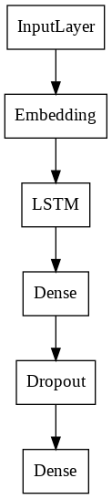

```python
tf.keras.utils.plot_model(
    model1, to_file='model.png', show_shapes=False, show_dtype=False,
    show_layer_names=False, rankdir='TB', expand_nested=False, dpi=96,
    layer_range=None, show_layer_activations=False
)
```

```python
!rm -rf ./logs/
```